# Krzysztof Basiński

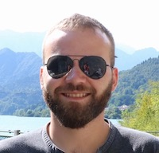

# O mnie

Jestem asystentem w Zakładzie Badań nad Jakością Życia Gdańskiego Uniwersytetu Medycznego. W pracy naukowej zajmuję się słyszeniem (w szczególności muzyki) oraz bólem (oraz związkami pomiędzy jednym a drugim). Aktualnie realizuję projekt *Wpływ preferencji muzycznych na zjawisko muzycznej analgezji* finansowany przez Narodowe Centrum Nauki (można o nim poczytać [tutaj](http://naukawpolsce.pap.pl/aktualnosci/news,410003,kogo-ukoi-disco-polo.html) albo [tutaj](https://projekty.ncn.gov.pl/index.php?s=12579%5D) ). Kończę też pracę nad rozprawą doktorską pt. *Ocena psychologicznych wyznaczników powstawania bólu przewlekłego u chorych z niespecyficznym bólem okolicy lędźwiowo-krzyżowej*.

Mam żonę i dwójkę dzieci. Jeśli mam wolną chwilę, lubię grać na gitarze, zwłaszcza muzykę amerykańską minionego wieku.

# Najważniejsze publikacje

Basinski, K., Zdun-Ryzewska, A., & Majkowicz, M. (2018). The role of musical attributes in music-induced analgesia: A preliminary brief report. Frontiers in Psychology, 9(SEP), 1–5. https://doi.org/10.3389/fpsyg.2018.01761 [link](https://www.frontiersin.org/articles/10.3389/fpsyg.2018.01761/full)

Chojnacka-Szawłowska, G., Majkowicz, M., Basiński, K., Zdun-Ryzewska, A., Wasilewko, I., & Pankiewicz, P. (2016). Knowledge of cancer symptoms and anxiety affect patient delay in seeking diagnosis in patients with heterogeneous cancer locations. Current Problems in Cancer. https://doi.org/10.1016/j.currproblcancer.2016.10.001 [link](http://doi.org/10.1016/j.currproblcancer.2016.10.001)

Gruszecki, M., Tkachenko, Y., Kot, J., Radkowski, M., Gruszecka, A., Basinski, K., … Winklewski, P. J. (2018). Coupling of Blood Pressure and Subarachnoid Space Oscillations at Cardiac Frequency Evoked by Handgrip and Cold Tests: A Bispectral Analysis. Advances in Experimental Medicine and Biology. https://doi.org/https://dx.doi.org/10.1007/5584_2018_283

Hansdorfer-Korzon, R., Chojnacka-Szawłowska, G., Landowski, J., Majkowicz, M., Basiński, K., Zdun-Ryżewska, A., & Wasilewko, I. (2016). Relationships of anxiety and depressive symptoms with pain perception in post-mastectomy women. An intragroup analysis. Revista de Psiquiatria Clinica, 43(4). https://doi.org/10.1590/0101-60830000000088

Zdun-Ryżewska, A., Basiński, K., Majkowicz, M., Podolska, M., Landowski, J., & Walden-Gałuszko, K. (2018). Association between social support and quality of life in patients with affective disorders. European Journal of Psychiatry. https://doi.org/10.1016/j.ejpsy.2018.05.002

# Dydaktyka / Teaching

- [Metodologia badań psychologicznych](http://kbas.gumed.edu.pl/mbp)
- [Technologie informatyczne w pracy naukowej](http://kbas.gumed.edu.pl/tipn)
- [Psychologia muzyki i muzykoterapia](http://kbas.gumed.edu.pl/psych_muz)
- [Music therapy and psychology of music](http://kbas.gumed.edu.pl/music_ther)
- Projekt badawczy
- [Wprowadzenie do psychologii społecznej](http://kbas.gumed.edu.pl/wdps/)

# Kontakt

krzysztof.basinski@gumed.edu.pl

Zakład Badań nad Jakością Życia

Gdański Uniwersytet Medyczny

ul. Tuwima 15, pok.312

80-210 Gdańsk

tel. +48 58 349 15 55 (sekretariat)